```r
set.seed(555)

library("ggplot2")
library("gridExtra")
library("fastDummies")
library("Metrics")
library("ggpubr")
library("tidyverse")
library("rpart")

library("fBasics")
library("caret")
library("rattle")
library("FNN")
library("scales")
library("reshape2")
```

Reading Pisa dataset

```r
dataset <- read.csv("pisa_israel_2018_fortargil.csv")
```

KNN algo

#### Data preprossesing

Before starting the data analysis I will so some data prepreprossecing - that will help me to avoid some upcoming problems.

Missing values

```r
#Check which columns have missing values

cols_missing <- names(which(colSums(is.na(dataset))>0))
print(paste0("Number of columns with missing values before NAs fill: ",length(cols_missing)))
```

```
## [1] "Number of columns with missing values before NAs fill: 12"
```

```r
#Computing all missing values to be the avg of its column.

for (i in cols_missing) {
  dataset[[i]] = ifelse(is.na(dataset[[i]]),
                     ave(dataset[[i]]
, FUN = function(x) mean(x, na.rm = TRUE)),
                     dataset[[i]])
}

missing_check <- names(which(colSums(is.na(dataset))>0))
print(paste0("Number of columns with missing values after NAs fill: ",length(missing_check)))
```

```
## [1] "Number of columns with missing values after NAs fill: 0"
```

The first step in the pre prossecing was to look which columns have NAs values. Becouse I saw that all of those columns are numeric (and not binary or categorical) I chose to fill their NAs with the mean value of each column.

Convert catagorical data to dummies variables

```r
for (val in unique(dataset$System)){
        unique_values = dataset[dataset$System==val,]
       }
       dataset[dataset$System==val,] = unique_values

    dataset <- dummy_columns(dataset, select_columns = c( 'System', 'LANGN'), remove_first_dummy = TRUE, remove_selected_columns = TRUE)
```

The second step was to find the categorical variables and transform them to dummies variables, in order to do this I was helped the FastDummies library.

Scales all numeric values into zero to one scale

```r
##I used this page in order to do the next scaling https://stackoverflow.com/questions/5665599/range-standardization-0-to-1-in-r.

scale_0_to_1 <- function(x){(x-min(x))/(max(x)-min(x))}

for (col in colnames(dataset)[2:length(colnames(dataset))]){dataset[[col]] = scale_0_to_1(dataset[[col]])}
```

Last step was to do feature scaling - to scale the data to have the same range - what helps me later to calculate more accourate distance between the students.

```r
print("Summary of dataset after preprossecing: ")
```

```
## [1] "Summary of dataset after preprossecing: "
```

```r
summary(dataset)
```

```
##      PVREAD           AGE            PAREDINT         EFFORT1
##  Min.   :142.5   Min.   :0.0000   Min.   :0.0000   Min.   :0.0000
##  1st Qu.:389.6   1st Qu.:0.2315   1st Qu.:0.6923   1st Qu.:0.6667
##  Median :485.4   Median :0.4630   Median :1.0000   Median :0.7778
##  Mean   :476.0   Mean   :0.4888   Mean   :0.8751   Mean   :0.7671
##  3rd Qu.:567.2   3rd Qu.:0.6944   3rd Qu.:1.0000   3rd Qu.:0.8889
##  Max.   :806.7   Max.   :1.0000   Max.   :1.0000   Max.   :1.0000
##     DURECEC            ESCS           JOYREAD          DISCLIMA
##  Min.   :0.0000   Min.   :0.0000   Min.   :0.0000   Min.   :0.0000
##  1st Qu.:0.3750   1st Qu.:0.6338   1st Qu.:0.4072   1st Qu.:0.4404
##  Median :0.3750   Median :0.7054   Median :0.5208   Median :0.5690
##  Mean   :0.3956   Mean   :0.6915   Mean   :0.5208   Mean   :0.5690
##  3rd Qu.:0.5000   3rd Qu.:0.7561   3rd Qu.:0.6239   3rd Qu.:0.6854
##  Max.   :1.0000   Max.   :1.0000   Max.   :1.0000   Max.   :1.0000
##     TEACHSUP          CLSIZE         STAFFSHORT        EDUSHORT
##  Min.   :0.0000   Min.   :0.0000   Min.   :0.0000   Min.   :0.0000
##  1st Qu.:0.4912   1st Qu.:0.4286   1st Qu.:0.1579   1st Qu.:0.2531
##  Median :0.6468   Median :0.5714   Median :0.3276   Median :0.3856
##  Mean   :0.6468   Mean   :0.5032   Mean   :0.3182   Mean   :0.3914
##  3rd Qu.:0.8434   3rd Qu.:0.5714   3rd Qu.:0.4299   3rd Qu.:0.5148
##  Max.   :1.0000   Max.   :1.0000   Max.   :1.0000   Max.   :1.0000
##      TOTAT           STRATIO        System_Israel Hebrew Religious
##  Min.   :0.0000   Min.   :0.00000   Min.   :0.0000
##  1st Qu.:0.2333   1st Qu.:0.08348   1st Qu.:0.0000
##  Median :0.3956   Median :0.10188   Median :0.0000
##  Mean   :0.3956   Mean   :0.11216   Mean   :0.1386
##  3rd Qu.:0.5167   3rd Qu.:0.11216   3rd Qu.:0.0000
##  Max.   :1.0000   Max.   :1.00000   Max.   :1.0000
##  System_Israel Hebrew Secular System_Israel Ultra Orthodox Girls
##  Min.   :0.0000               Min.   :0.00000
##  1st Qu.:0.0000               1st Qu.:0.00000
##  Median :1.0000               Median :0.00000
##  Mean   :0.5147               Mean   :0.09977
##  3rd Qu.:1.0000               3rd Qu.:0.00000
##  Max.   :1.0000               Max.   :1.00000
##    LANGN_171          LANGN_313         LANGN_422        LANGN_493
##  Min.   :0.000000   Min.   :0.00000   Min.   :0.0000   Min.   :0.000000
##  1st Qu.:0.000000   1st Qu.:0.00000   1st Qu.:0.0000   1st Qu.:0.000000
##  Median :0.000000   Median :0.00000   Median :1.0000   Median :0.000000
##  Mean   :0.005953   Mean   :0.02778   Mean   :0.6509   Mean   :0.007036
##  3rd Qu.:0.000000   3rd Qu.:0.00000   3rd Qu.:1.0000   3rd Qu.:0.000000
##  Max.   :1.000000   Max.   :1.00000   Max.   :1.0000   Max.   :1.000000
##    LANGN_500        LANGN_614         LANGN_825         LANGN_999
##  Min.   :0.0000   Min.   :0.00000   Min.   :0.00000   Min.   :0.00000
##  1st Qu.:0.0000   1st Qu.:0.00000   1st Qu.:0.00000   1st Qu.:0.00000
##  Median :0.0000   Median :0.00000   Median :0.00000   Median :0.00000
##  Mean   :0.2109   Mean   :0.04564   Mean   :0.01552   Mean   :0.02995
##  3rd Qu.:0.0000   3rd Qu.:0.00000   3rd Qu.:0.00000   3rd Qu.:0.00000
##  Max.   :1.0000   Max.   :1.00000   Max.   :1.00000   Max.   :1.00000
```

In this summary we see the data after the preproccesing - we can see that there is no Nas anymore, all the catergorical became Dummis and all the precitors are scaled from zero to one.

Distance functions based on class and students levels:

```r
student_levels <- c('AGE', 'PAREDINT', 'EFFORT1', 'DURECEC', 'ESCS', 'JOYREAD', 'DISCLIMA', 'TEACHSUP','LANGN_171','LANGN_313','LANGN_422','LANGN_493','LANGN_500','LANGN_614','LANGN_825', 'LANGN_999')

class_levels <- c('CLSIZE', 'STAFFSHORT', 'EDUSHORT', 'TOTAT', 'STRATIO', 'System_Israel Hebrew Religious', 'System_Israel Hebrew Secular', 'System_Israel Ultra Orthodox Girls')

print(paste("student levels: ",str(student_levels)))
```

```
##  chr [1:16] "AGE" "PAREDINT" "EFFORT1" "DURECEC" "ESCS" "JOYREAD" ...
## [1] "student levels:  "
```

```r
print(paste("class levels: ",str(class_levels)))
```

```
##  chr [1:8] "CLSIZE" "STAFFSHORT" "EDUSHORT" "TOTAT" "STRATIO" ...
## [1] "class levels:  "
```

First step in order to calculate the distance between the two group was to find manually the class and students levels, as showed above.

Distance between students levels and class levels:

```r
student_level_d <- function(train,test, levels = student_levels){
    train <- train[,student_levels]
    test <- test[,student_levels]
    student_d <- apply(test, 1, function(x) apply(train, 1, function(y) sqrt(crossprod(x-y))))
    return(student_d)
}

class_level_d <- function(train, test, levels =class_levels){
    train <- train[,class_levels]
    test <- test[,class_levels]
    class_d <- apply(test, 1, function(x) apply(train, 1, function(y) sqrt(crossprod(x-y))))
    return(class_d)
}
```

In order to build the distance functions I was helped by this link - https://stackoverflow.com/questions/57823228/how-to-use-apply-function-to-calculate-the-distance-between-two-matrices

KNN algorithm

```r
KNN_algo <- function(k, d_student, d_class, a, train, test){

  dist <- a*d_student(train, test, student_levels) + (1-a)* d_class(train, test, class_levels)

  #taking only the k nearest nighboures
  knn <- head(sort(dist ,index.return = TRUE)$ix,k)

  #taking the mean of thier values.
  knn_p <- apply(train[knn, 1, drop=F],MARGIN = 2 ,FUN =  mean)

  return(as.numeric(knn_p))
}

ind_train <- sample(nrow(dataset),ceiling(nrow(dataset)*0.8),replace=FALSE)
 train <- dataset[ind_train,]
 test <- dataset[-ind_train,]
```

This function gets a k value which represnt how many nearest nighboruos we are based on, the two distance function, an a which represnt the wieght of the student / class distance, the train and the test datasets.

The first step is to calculate the full distance based on the furmula that we got in the ecxercise, after having the all points ditance I sorted it in order to get the most closest point, and saved in the knn val the k closest neighbours. last step was to calculate the mean of those knn and to return it.

Errors functions for different k & a values

```r
set.seed(555)

error_fun <- function(dataset, ks, as){
 ind_train <- sample(nrow(dataset),ceiling(nrow(dataset)*0.8),replace=FALSE)
 train <- dataset[ind_train,]
 test <- dataset[-ind_train,]
        errors <- c()
        for (i in 1:nrow(test)){
           pred <- KNN_algo(k = ks,student_level_d, class_level_d, a = as, train , test[i,])
           rse <- rmse(test[i, 1],pred)
           errors <- c(errors, rse)
        }
      return (mean(unlist(errors)))
      }
```

This function gets a dataset, k and a. first it’s deviding the data into train and test, than it goes through the test rows and find the predicted value for each test point, after that it finds the rmse between specific point to its predicted value and at the end return the mean of the rmse list for this test set.

Create a df with the errors values for different k’s and a’s:

```r
set.seed(555)


ks= c(1,3,5,9)
as= c(0.1,0.3,0.5,0.9)

 errors <- matrix(nrow =length(ks), ncol=length(as))
 for(k in 1:length(ks)){
    for (a in 1:length(as)){
              errors[k,a] <- error_fun(dataset,ks[k],as[a])
    }}

 errors <- as.data.frame(errors)
 rownames(errors) <- ks
 colnames(errors) <- as
```

In this part I chose four values for each a and k, than I created a matrix to save the rmse for each a and k combination, based on the function above.

Plot of the rmse of all the k and a combinations.

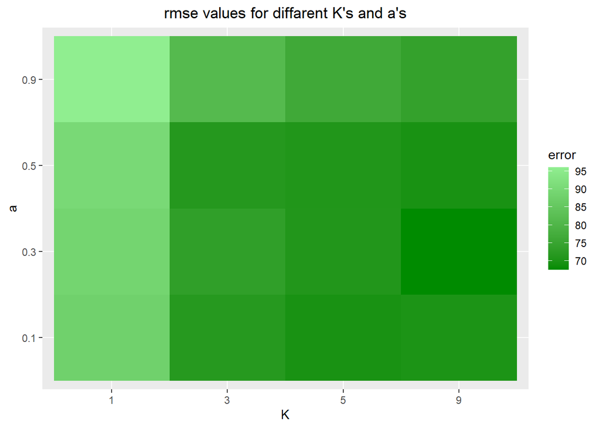

```r
errors_p <- errors %>%

  tibble::rownames_to_column() %>%

  tidyr::gather(value, colname,-rowname)

  colnames(errors_p) <- c('ks', 'as', 'error')

ggplot(errors_p, aes(x = as.factor(ks), y = as.factor(as), fill = error)) +
  geom_tile() +
  theme(plot.title = element_text(hjust = 0.5))+
  scale_fill_gradient(low="green4", high="lightgreen") +
  labs( x= 'K', y = 'a', title = "rmse values for diffarent K's and a's")
```

In order to do this graph I used this link - https://monashbioinformaticsplatform.github.io/r-more/topics/tidyverse.html

In this fig we see an heatmap of the estimated errors for different values of a’s and k’s. I chose to color the smallest errors value in stronger color then the greater errors becouse it represent a better prediction. we can see that in k=1, the a doesnt ifluence much on the graph and we get the weekest prediction, the other three options of k get much better(lower) rmse’s values, with an advantage to k=9,a=0.3.

About the comparison between the rmse values to the sd of PVread score (sd(dataset$PVREAD) : 120.4118 ), I can say that the rmse’s whole range is smaller then the sd, what means that the model works well, beacouse the explainable variance is greater then the unexplainable variance in this model. The lower rmse we’ll get, the better the model will be.